# Risk Factor Analysis

## Outcome Variable

**Outcome Variable:** wast_rec90d

## Predictor Variables

**Intervention Variable:** enstunt

**Adjustment Set:**

- arm
- sex
- W_mage
- meducyrs
- feducyrs
- vagbrth
- brthmon
- W_parity
- delta_W_mage
- delta_meducyrs
- delta_feducyrs
- delta_vagbrth
- delta_brthmon
- delta_W_parity

## Stratifying Variables

The analysis was stratified on these variable(s):

- agecat
- studyid
- country

## Data Summary

| agecat | studyid | country | enstunt | wast_rec90d | n_cell | n |
| --- | --- | --- | --- | --- | --- | --- |
| 0-24 months | ki0047075b-MAL-ED | BANGLADESH | 0 | 0 | 34 | 124 |
| 0-24 months | ki0047075b-MAL-ED | BANGLADESH | 0 | 1 | 61 | 124 |
| 0-24 months | ki0047075b-MAL-ED | BANGLADESH | 1 | 0 | 11 | 124 |
| 0-24 months | ki0047075b-MAL-ED | BANGLADESH | 1 | 1 | 18 | 124 |
| 0-24 months | ki0047075b-MAL-ED | BRAZIL | 0 | 0 | 5 | 23 |
| 0-24 months | ki0047075b-MAL-ED | BRAZIL | 0 | 1 | 15 | 23 |
| 0-24 months | ki0047075b-MAL-ED | BRAZIL | 1 | 0 | 1 | 23 |
| 0-24 months | ki0047075b-MAL-ED | BRAZIL | 1 | 1 | 2 | 23 |
| 0-24 months | ki0047075b-MAL-ED | INDIA | 0 | 0 | 51 | 178 |
| 0-24 months | ki0047075b-MAL-ED | INDIA | 0 | 1 | 89 | 178 |
| 0-24 months | ki0047075b-MAL-ED | INDIA | 1 | 0 | 20 | 178 |
| 0-24 months | ki0047075b-MAL-ED | INDIA | 1 | 1 | 18 | 178 |
| 0-24 months | ki0047075b-MAL-ED | NEPAL | 0 | 0 | 16 | 93 |
| 0-24 months | ki0047075b-MAL-ED | NEPAL | 0 | 1 | 59 | 93 |
| 0-24 months | ki0047075b-MAL-ED | NEPAL | 1 | 0 | 4 | 93 |
| 0-24 months | ki0047075b-MAL-ED | NEPAL | 1 | 1 | 14 | 93 |
| 0-24 months | ki0047075b-MAL-ED | PERU | 0 | 0 | 3 | 34 |
| 0-24 months | ki0047075b-MAL-ED | PERU | 0 | 1 | 20 | 34 |
| 0-24 months | ki0047075b-MAL-ED | PERU | 1 | 0 | 3 | 34 |
| 0-24 months | ki0047075b-MAL-ED | PERU | 1 | 1 | 8 | 34 |
| 0-24 months | ki0047075b-MAL-ED | SOUTH AFRICA | 0 | 0 | 16 | 83 |
| 0-24 months | ki0047075b-MAL-ED | SOUTH AFRICA | 0 | 1 | 54 | 83 |
| 0-24 months | ki0047075b-MAL-ED | SOUTH AFRICA | 1 | 0 | 1 | 83 |
| 0-24 months | ki0047075b-MAL-ED | SOUTH AFRICA | 1 | 1 | 12 | 83 |
| 0-24 months | ki0047075b-MAL-ED | TANZANIA, UNITED REPUBLIC OF | 0 | 0 | 7 | 45 |
| 0-24 months | ki0047075b-MAL-ED | TANZANIA, UNITED REPUBLIC OF | 0 | 1 | 28 | 45 |
| 0-24 months | ki0047075b-MAL-ED | TANZANIA, UNITED REPUBLIC OF | 1 | 0 | 1 | 45 |
| 0-24 months | ki0047075b-MAL-ED | TANZANIA, UNITED REPUBLIC OF | 1 | 1 | 9 | 45 |
| 0-24 months | ki1000108-CMC-V-BCS-2002 | INDIA | 0 | 0 | 88 | 326 |
| 0-24 months | ki1000108-CMC-V-BCS-2002 | INDIA | 0 | 1 | 163 | 326 |

[output cut: 374 more lines]

The following strata were considered:

- agecat: 0-24 months, studyid: ki0047075b-MAL-ED, country: BANGLADESH
- agecat: 0-24 months, studyid: ki0047075b-MAL-ED, country: BRAZIL
- agecat: 0-24 months, studyid: ki0047075b-MAL-ED, country: INDIA
- agecat: 0-24 months, studyid: ki0047075b-MAL-ED, country: NEPAL
- agecat: 0-24 months, studyid: ki0047075b-MAL-ED, country: PERU
- agecat: 0-24 months, studyid: ki0047075b-MAL-ED, country: SOUTH AFRICA
- agecat: 0-24 months, studyid: ki0047075b-MAL-ED, country: TANZANIA, UNITED REPUBLIC OF
- agecat: 0-24 months, studyid: ki1000108-CMC-V-BCS-2002, country: INDIA
- agecat: 0-24 months, studyid: ki1000108-IRC, country: INDIA
- agecat: 0-24 months, studyid: ki1000109-EE, country: PAKISTAN
- agecat: 0-24 months, studyid: ki1000109-ResPak, country: PAKISTAN
- agecat: 0-24 months, studyid: ki1000304b-SAS-CompFeed, country: INDIA
- agecat: 0-24 months, studyid: ki1000304b-SAS-FoodSuppl, country: INDIA
- agecat: 0-24 months, studyid: ki1017093-NIH-Birth, country: BANGLADESH
- agecat: 0-24 months, studyid: ki1017093b-PROVIDE, country: BANGLADESH
- agecat: 0-24 months, studyid: ki1017093c-NIH-Crypto, country: BANGLADESH
- agecat: 0-24 months, studyid: ki1066203-TanzaniaChild2, country: TANZANIA, UNITED REPUBLIC OF
- agecat: 0-24 months, studyid: ki1101329-Keneba, country: GAMBIA
- agecat: 0-24 months, studyid: ki1112895-Guatemala BSC, country: GUATEMALA
- agecat: 0-24 months, studyid: ki1112895-iLiNS-Zinc, country: BURKINA FASO
- agecat: 0-24 months, studyid: ki1113344-GMS-Nepal, country: NEPAL
- agecat: 0-24 months, studyid: ki1114097-CMIN, country: BANGLADESH
- agecat: 0-24 months, studyid: ki1114097-CMIN, country: BRAZIL
- agecat: 0-24 months, studyid: ki1114097-CMIN, country: GUINEA-BISSAU
- agecat: 0-24 months, studyid: ki1114097-CMIN, country: PERU
- agecat: 0-24 months, studyid: ki1114097-CONTENT, country: PERU
- agecat: 0-24 months, studyid: ki1119695-PROBIT, country: BELARUS
- agecat: 0-24 months, studyid: ki1126311-ZVITAMBO, country: ZIMBABWE
- agecat: 0-24 months, studyid: ki1135781-COHORTS, country: GUATEMALA
- agecat: 0-24 months, studyid: ki1135781-COHORTS, country: INDIA
- agecat: 0-24 months, studyid: ki1135781-COHORTS, country: PHILIPPINES
- agecat: 0-24 months, studyid: ki1148112-LCNI-5, country: MALAWI
- agecat: 0-24 months, studyid: kiGH5241-JiVitA-3, country: BANGLADESH
- agecat: 0-24 months, studyid: kiGH5241-JiVitA-4, country: BANGLADESH
- agecat: 0-6 months, studyid: ki0047075b-MAL-ED, country: BANGLADESH
- agecat: 0-6 months, studyid: ki0047075b-MAL-ED, country: BRAZIL
- agecat: 0-6 months, studyid: ki0047075b-MAL-ED, country: INDIA
- agecat: 0-6 months, studyid: ki0047075b-MAL-ED, country: NEPAL
- agecat: 0-6 months, studyid: ki0047075b-MAL-ED, country: PERU
- agecat: 0-6 months, studyid: ki0047075b-MAL-ED, country: SOUTH AFRICA
- agecat: 0-6 months, studyid: ki0047075b-MAL-ED, country: TANZANIA, UNITED REPUBLIC OF
- agecat: 0-6 months, studyid: ki1000108-CMC-V-BCS-2002, country: INDIA
- agecat: 0-6 months, studyid: ki1000108-IRC, country: INDIA
- agecat: 0-6 months, studyid: ki1000109-EE, country: PAKISTAN
- agecat: 0-6 months, studyid: ki1000109-ResPak, country: PAKISTAN
- agecat: 0-6 months, studyid: ki1000304b-SAS-CompFeed, country: INDIA
- agecat: 0-6 months, studyid: ki1000304b-SAS-FoodSuppl, country: INDIA
- agecat: 0-6 months, studyid: ki1017093-NIH-Birth, country: BANGLADESH
- agecat: 0-6 months, studyid: ki1017093b-PROVIDE, country: BANGLADESH
- agecat: 0-6 months, studyid: ki1017093c-NIH-Crypto, country: BANGLADESH
- agecat: 0-6 months, studyid: ki1066203-TanzaniaChild2, country: TANZANIA, UNITED REPUBLIC OF
- agecat: 0-6 months, studyid: ki1101329-Keneba, country: GAMBIA
- agecat: 0-6 months, studyid: ki1112895-Guatemala BSC, country: GUATEMALA
- agecat: 0-6 months, studyid: ki1113344-GMS-Nepal, country: NEPAL
- agecat: 0-6 months, studyid: ki1114097-CMIN, country: BANGLADESH
- agecat: 0-6 months, studyid: ki1114097-CMIN, country: BRAZIL
- agecat: 0-6 months, studyid: ki1114097-CMIN, country: GUINEA-BISSAU
- agecat: 0-6 months, studyid: ki1114097-CMIN, country: PERU
- agecat: 0-6 months, studyid: ki1114097-CONTENT, country: PERU
- agecat: 0-6 months, studyid: ki1119695-PROBIT, country: BELARUS
- agecat: 0-6 months, studyid: ki1126311-ZVITAMBO, country: ZIMBABWE
- agecat: 0-6 months, studyid: ki1135781-COHORTS, country: GUATEMALA
- agecat: 0-6 months, studyid: ki1135781-COHORTS, country: INDIA
- agecat: 0-6 months, studyid: ki1135781-COHORTS, country: PHILIPPINES
- agecat: 0-6 months, studyid: ki1148112-LCNI-5, country: MALAWI
- agecat: 0-6 months, studyid: kiGH5241-JiVitA-3, country: BANGLADESH
- agecat: 0-6 months, studyid: kiGH5241-JiVitA-4, country: BANGLADESH
- agecat: 6-24 months, studyid: ki0047075b-MAL-ED, country: BANGLADESH
- agecat: 6-24 months, studyid: ki0047075b-MAL-ED, country: BRAZIL
- agecat: 6-24 months, studyid: ki0047075b-MAL-ED, country: INDIA
- agecat: 6-24 months, studyid: ki0047075b-MAL-ED, country: NEPAL
- agecat: 6-24 months, studyid: ki0047075b-MAL-ED, country: PERU
- agecat: 6-24 months, studyid: ki0047075b-MAL-ED, country: SOUTH AFRICA
- agecat: 6-24 months, studyid: ki0047075b-MAL-ED, country: TANZANIA, UNITED REPUBLIC OF
- agecat: 6-24 months, studyid: ki1000108-CMC-V-BCS-2002, country: INDIA
- agecat: 6-24 months, studyid: ki1000108-IRC, country: INDIA
- agecat: 6-24 months, studyid: ki1000109-EE, country: PAKISTAN
- agecat: 6-24 months, studyid: ki1000109-ResPak, country: PAKISTAN
- agecat: 6-24 months, studyid: ki1000304b-SAS-CompFeed, country: INDIA
- agecat: 6-24 months, studyid: ki1000304b-SAS-FoodSuppl, country: INDIA
- agecat: 6-24 months, studyid: ki1017093-NIH-Birth, country: BANGLADESH
- agecat: 6-24 months, studyid: ki1017093b-PROVIDE, country: BANGLADESH
- agecat: 6-24 months, studyid: ki1017093c-NIH-Crypto, country: BANGLADESH
- agecat: 6-24 months, studyid: ki1066203-TanzaniaChild2, country: TANZANIA, UNITED REPUBLIC OF
- agecat: 6-24 months, studyid: ki1101329-Keneba, country: GAMBIA
- agecat: 6-24 months, studyid: ki1112895-Guatemala BSC, country: GUATEMALA
- agecat: 6-24 months, studyid: ki1112895-iLiNS-Zinc, country: BURKINA FASO
- agecat: 6-24 months, studyid: ki1113344-GMS-Nepal, country: NEPAL
- agecat: 6-24 months, studyid: ki1114097-CMIN, country: BANGLADESH
- agecat: 6-24 months, studyid: ki1114097-CMIN, country: BRAZIL
- agecat: 6-24 months, studyid: ki1114097-CMIN, country: GUINEA-BISSAU
- agecat: 6-24 months, studyid: ki1114097-CMIN, country: PERU
- agecat: 6-24 months, studyid: ki1114097-CONTENT, country: PERU
- agecat: 6-24 months, studyid: ki1119695-PROBIT, country: BELARUS
- agecat: 6-24 months, studyid: ki1126311-ZVITAMBO, country: ZIMBABWE
- agecat: 6-24 months, studyid: ki1135781-COHORTS, country: GUATEMALA
- agecat: 6-24 months, studyid: ki1135781-COHORTS, country: INDIA
- agecat: 6-24 months, studyid: ki1135781-COHORTS, country: PHILIPPINES
- agecat: 6-24 months, studyid: ki1148112-LCNI-5, country: MALAWI
- agecat: 6-24 months, studyid: kiGH5241-JiVitA-3, country: BANGLADESH
- agecat: 6-24 months, studyid: kiGH5241-JiVitA-4, country: BANGLADESH

### Dropped Strata

Some strata were dropped due to rare outcomes:

- agecat: 0-24 months, studyid: ki0047075b-MAL-ED, country: BRAZIL
- agecat: 0-24 months, studyid: ki0047075b-MAL-ED, country: NEPAL
- agecat: 0-24 months, studyid: ki0047075b-MAL-ED, country: PERU
- agecat: 0-24 months, studyid: ki0047075b-MAL-ED, country: SOUTH AFRICA
- agecat: 0-24 months, studyid: ki0047075b-MAL-ED, country: TANZANIA, UNITED REPUBLIC OF
- agecat: 0-24 months, studyid: ki1000304b-SAS-FoodSuppl, country: INDIA
- agecat: 0-24 months, studyid: ki1114097-CMIN, country: BRAZIL
- agecat: 0-24 months, studyid: ki1114097-CONTENT, country: PERU
- agecat: 0-24 months, studyid: ki1119695-PROBIT, country: BELARUS
- agecat: 0-24 months, studyid: ki1135781-COHORTS, country: GUATEMALA
- agecat: 0-6 months, studyid: ki0047075b-MAL-ED, country: BANGLADESH
- agecat: 0-6 months, studyid: ki0047075b-MAL-ED, country: BRAZIL
- agecat: 0-6 months, studyid: ki0047075b-MAL-ED, country: INDIA
- agecat: 0-6 months, studyid: ki0047075b-MAL-ED, country: NEPAL
- agecat: 0-6 months, studyid: ki0047075b-MAL-ED, country: PERU
- agecat: 0-6 months, studyid: ki0047075b-MAL-ED, country: SOUTH AFRICA
- agecat: 0-6 months, studyid: ki0047075b-MAL-ED, country: TANZANIA, UNITED REPUBLIC OF
- agecat: 0-6 months, studyid: ki1000304b-SAS-FoodSuppl, country: INDIA
- agecat: 0-6 months, studyid: ki1017093c-NIH-Crypto, country: BANGLADESH
- agecat: 0-6 months, studyid: ki1066203-TanzaniaChild2, country: TANZANIA, UNITED REPUBLIC OF
- agecat: 0-6 months, studyid: ki1112895-Guatemala BSC, country: GUATEMALA
- agecat: 0-6 months, studyid: ki1114097-CMIN, country: BRAZIL
- agecat: 0-6 months, studyid: ki1114097-CMIN, country: GUINEA-BISSAU
- agecat: 0-6 months, studyid: ki1114097-CMIN, country: PERU
- agecat: 0-6 months, studyid: ki1114097-CONTENT, country: PERU
- agecat: 0-6 months, studyid: ki1119695-PROBIT, country: BELARUS
- agecat: 0-6 months, studyid: ki1135781-COHORTS, country: GUATEMALA
- agecat: 0-6 months, studyid: ki1148112-LCNI-5, country: MALAWI
- agecat: 6-24 months, studyid: ki0047075b-MAL-ED, country: BRAZIL
- agecat: 6-24 months, studyid: ki0047075b-MAL-ED, country: NEPAL
- agecat: 6-24 months, studyid: ki0047075b-MAL-ED, country: PERU
- agecat: 6-24 months, studyid: ki0047075b-MAL-ED, country: SOUTH AFRICA
- agecat: 6-24 months, studyid: ki0047075b-MAL-ED, country: TANZANIA, UNITED REPUBLIC OF
- agecat: 6-24 months, studyid: ki1000304b-SAS-FoodSuppl, country: INDIA
- agecat: 6-24 months, studyid: ki1017093c-NIH-Crypto, country: BANGLADESH
- agecat: 6-24 months, studyid: ki1114097-CMIN, country: BRAZIL
- agecat: 6-24 months, studyid: ki1114097-CONTENT, country: PERU
- agecat: 6-24 months, studyid: ki1119695-PROBIT, country: BELARUS
- agecat: 6-24 months, studyid: ki1135781-COHORTS, country: GUATEMALA
- agecat: 6-24 months, studyid: ki1135781-COHORTS, country: INDIA
- agecat: 6-24 months, studyid: kiGH5241-JiVitA-3, country: BANGLADESH

## Methods Detail

We’re interested in the causal parameters $E[Y_a]$ for all values of $a \in \mathcal{A}$. These parameters represent the mean outcome if, possibly contrary to fact, we intervened to set all units to have $A=a$. Under the randomization and positivity assumptions, these are identified by the statistical parameters $\psi_a=E_W[E_{Y|A,W}(Y|A=a,W)]$. In addition, we’re interested in the mean of $Y$, $E[Y]$ under no intervention (the observed mean). We will estimate these parameters by using SuperLearner to fit the relevant likelihood factors – $E_{Y|A,W}(Y|A=a,W)$ and $p(A=a|W)$, and then updating our likelihood fit using a joint TMLE.

For unadjusted analyses ($W=\{\}$), initial likelihoods were estimated using Lrnr_glm to estimate the simple $E(Y|A)$ and Lrnr_mean to estimate $p(A)$. For adjusted analyses, a small library containing Lrnr_glmnet, Lrnr_xgboost, and Lrnr_mean was used.

Having estimated these parameters, we will then use the delta method to estimate relative risks and attributable risks relative to a prespecified baseline level of $A$.

# Results Detail

## Results Plots

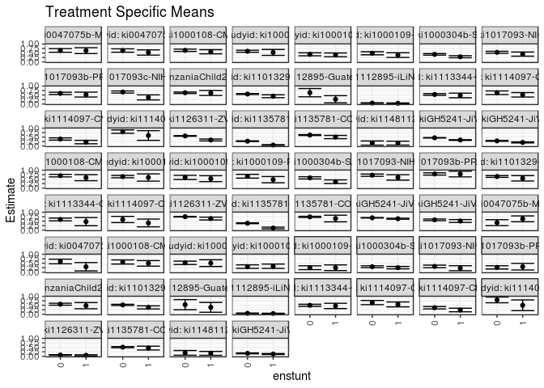

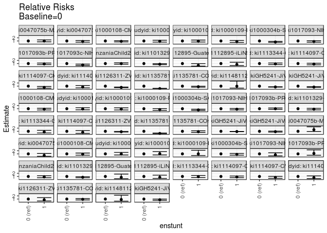

[figure not shown]

[figure not shown]

## Results Table

### Parameter: TSM

| agecat | studyid | country | intervention_level | baseline_level | estimate | ci_lower | ci_upper |
| --- | --- | --- | --- | --- | --- | --- | --- |
| 0-24 months | ki0047075b-MAL-ED | BANGLADESH | 0 | NA | 0.6417729 | 0.5407312 | 0.7428145 |
| 0-24 months | ki0047075b-MAL-ED | BANGLADESH | 1 | NA | 0.6304000 | 0.4661818 | 0.7946181 |
| 0-24 months | ki0047075b-MAL-ED | INDIA | 0 | NA | 0.6373785 | 0.5439715 | 0.7307854 |
| 0-24 months | ki0047075b-MAL-ED | INDIA | 1 | NA | 0.5270480 | 0.3809453 | 0.6731508 |
| 0-24 months | ki1000108-CMC-V-BCS-2002 | INDIA | 0 | NA | 0.6507006 | 0.5866778 | 0.7147234 |
| 0-24 months | ki1000108-CMC-V-BCS-2002 | INDIA | 1 | NA | 0.5680233 | 0.4524582 | 0.6835883 |
| 0-24 months | ki1000108-IRC | INDIA | 0 | NA | 0.5963071 | 0.5407666 | 0.6518475 |
| 0-24 months | ki1000108-IRC | INDIA | 1 | NA | 0.5315023 | 0.3671839 | 0.6958208 |
| 0-24 months | ki1000109-EE | PAKISTAN | 0 | NA | 0.4264060 | 0.3434316 | 0.5093804 |
| 0-24 months | ki1000109-EE | PAKISTAN | 1 | NA | 0.3961064 | 0.2911105 | 0.5011024 |
| 0-24 months | ki1000109-ResPak | PAKISTAN | 0 | NA | 0.4839943 | 0.3981718 | 0.5698167 |
| 0-24 months | ki1000109-ResPak | PAKISTAN | 1 | NA | 0.3823707 | 0.2517219 | 0.5130195 |
| 0-24 months | ki1000304b-SAS-CompFeed | INDIA | 0 | NA | 0.4229905 | 0.3797175 | 0.4662634 |
| 0-24 months | ki1000304b-SAS-CompFeed | INDIA | 1 | NA | 0.2896590 | 0.2319234 | 0.3473946 |
| 0-24 months | ki1017093-NIH-Birth | BANGLADESH | 0 | NA | 0.5370400 | 0.4805073 | 0.5935728 |
| 0-24 months | ki1017093-NIH-Birth | BANGLADESH | 1 | NA | 0.4373132 | 0.3213599 | 0.5532665 |
| 0-24 months | ki1017093b-PROVIDE | BANGLADESH | 0 | NA | 0.5916599 | 0.5286874 | 0.6546323 |
| 0-24 months | ki1017093b-PROVIDE | BANGLADESH | 1 | NA | 0.5234849 | 0.3880773 | 0.6588925 |
| 0-24 months | ki1017093c-NIH-Crypto | BANGLADESH | 0 | NA | 0.6668589 | 0.6089996 | 0.7247182 |
| 0-24 months | ki1017093c-NIH-Crypto | BANGLADESH | 1 | NA | 0.3690742 | 0.2283887 | 0.5097597 |
| 0-24 months | ki1066203-TanzaniaChild2 | TANZANIA, UNITED REPUBLIC OF | 0 | NA | 0.6280661 | 0.5888262 | 0.6673061 |
| 0-24 months | ki1066203-TanzaniaChild2 | TANZANIA, UNITED REPUBLIC OF | 1 | NA | 0.6157330 | 0.4764577 | 0.7550083 |
| 0-24 months | ki1101329-Keneba | GAMBIA | 0 | NA | 0.5556333 | 0.5266518 | 0.5846147 |
| 0-24 months | ki1101329-Keneba | GAMBIA | 1 | NA | 0.4331509 | 0.3522846 | 0.5140172 |
| 0-24 months | ki1112895-Guatemala BSC | GUATEMALA | 0 | NA | 0.6315789 | 0.4004047 | 0.8627532 |
| 0-24 months | ki1112895-Guatemala BSC | GUATEMALA | 1 | NA | 0.2631579 | 0.0627483 | 0.4635675 |
| 0-24 months | ki1112895-iLiNS-Zinc | BURKINA FASO | 0 | NA | 0.0499411 | 0.0307189 | 0.0691633 |
| 0-24 months | ki1112895-iLiNS-Zinc | BURKINA FASO | 1 | NA | 0.0361496 | 0.0160964 | 0.0562027 |
| 0-24 months | ki1113344-GMS-Nepal | NEPAL | 0 | NA | 0.5315395 | 0.4836849 | 0.5793941 |
| 0-24 months | ki1113344-GMS-Nepal | NEPAL | 1 | NA | 0.4769403 | 0.3485500 | 0.6053306 |

[output cut: 90 more lines]

### Parameter: E(Y)

| agecat | studyid | country | intervention_level | baseline_level | estimate | ci_lower | ci_upper |
| --- | --- | --- | --- | --- | --- | --- | --- |
| 0-24 months | ki0047075b-MAL-ED | BANGLADESH | NA | NA | 0.6370968 | 0.5511492 | 0.7230443 |
| 0-24 months | ki0047075b-MAL-ED | INDIA | NA | NA | 0.6011236 | 0.5212729 | 0.6809743 |
| 0-24 months | ki1000108-CMC-V-BCS-2002 | INDIA | NA | NA | 0.6319018 | 0.5759256 | 0.6878781 |
| 0-24 months | ki1000108-IRC | INDIA | NA | NA | 0.5898734 | 0.5376978 | 0.6420491 |
| 0-24 months | ki1000109-EE | PAKISTAN | NA | NA | 0.4163424 | 0.3511349 | 0.4815500 |
| 0-24 months | ki1000109-ResPak | PAKISTAN | NA | NA | 0.4550000 | 0.3826235 | 0.5273765 |
| 0-24 months | ki1000304b-SAS-CompFeed | INDIA | NA | NA | 0.3808354 | 0.3457640 | 0.4159068 |
| 0-24 months | ki1017093-NIH-Birth | BANGLADESH | NA | NA | 0.5201900 | 0.4695846 | 0.5707955 |
| 0-24 months | ki1017093b-PROVIDE | BANGLADESH | NA | NA | 0.5830619 | 0.5262762 | 0.6398476 |
| 0-24 months | ki1017093c-NIH-Crypto | BANGLADESH | NA | NA | 0.6237942 | 0.5698223 | 0.6777662 |
| 0-24 months | ki1066203-TanzaniaChild2 | TANZANIA, UNITED REPUBLIC OF | NA | NA | 0.6269285 | 0.5892870 | 0.6645700 |
| 0-24 months | ki1101329-Keneba | GAMBIA | NA | NA | 0.5394218 | 0.5121870 | 0.5666566 |
| 0-24 months | ki1112895-Guatemala BSC | GUATEMALA | NA | NA | 0.4473684 | 0.2760904 | 0.6186464 |
| 0-24 months | ki1112895-iLiNS-Zinc | BURKINA FASO | NA | NA | 0.0439024 | 0.0298653 | 0.0579396 |
| 0-24 months | ki1113344-GMS-Nepal | NEPAL | NA | NA | 0.5222816 | 0.4773852 | 0.5671781 |
| 0-24 months | ki1114097-CMIN | BANGLADESH | NA | NA | 0.5789474 | 0.5004470 | 0.6574477 |
| 0-24 months | ki1114097-CMIN | GUINEA-BISSAU | NA | NA | 0.3502994 | 0.2972456 | 0.4033532 |
| 0-24 months | ki1114097-CMIN | PERU | NA | NA | 0.7659574 | 0.6722800 | 0.8596349 |
| 0-24 months | ki1126311-ZVITAMBO | ZIMBABWE | NA | NA | 0.5440559 | 0.5275873 | 0.5605246 |
| 0-24 months | ki1135781-COHORTS | INDIA | NA | NA | 0.2418325 | 0.2254819 | 0.2581831 |
| 0-24 months | ki1135781-COHORTS | PHILIPPINES | NA | NA | 0.6068680 | 0.5823645 | 0.6313715 |
| 0-24 months | ki1148112-LCNI-5 | MALAWI | NA | NA | 0.1645570 | 0.0832789 | 0.2458350 |
| 0-24 months | kiGH5241-JiVitA-3 | BANGLADESH | NA | NA | 0.4223102 | 0.4111919 | 0.4334286 |
| 0-24 months | kiGH5241-JiVitA-4 | BANGLADESH | NA | NA | 0.2585790 | 0.2392503 | 0.2779077 |
| 0-6 months | ki1000108-CMC-V-BCS-2002 | INDIA | NA | NA | 0.6748768 | 0.6092233 | 0.7405304 |
| 0-6 months | ki1000108-IRC | INDIA | NA | NA | 0.6375000 | 0.5751450 | 0.6998550 |
| 0-6 months | ki1000109-EE | PAKISTAN | NA | NA | 0.5648148 | 0.4692893 | 0.6603404 |
| 0-6 months | ki1000109-ResPak | PAKISTAN | NA | NA | 0.6160714 | 0.5252688 | 0.7068741 |
| 0-6 months | ki1000304b-SAS-CompFeed | INDIA | NA | NA | 0.5131965 | 0.4596632 | 0.5667297 |
| 0-6 months | ki1017093-NIH-Birth | BANGLADESH | NA | NA | 0.7130045 | 0.6535890 | 0.7724200 |
| 0-6 months | ki1017093b-PROVIDE | BANGLADESH | NA | NA | 0.7880435 | 0.7295878 | 0.8464992 |
| 0-6 months | ki1101329-Keneba | GAMBIA | NA | NA | 0.6346154 | 0.5881865 | 0.6810443 |
| 0-6 months | ki1113344-GMS-Nepal | NEPAL | NA | NA | 0.5833333 | 0.5108676 | 0.6557991 |
| 0-6 months | ki1114097-CMIN | BANGLADESH | NA | NA | 0.5192308 | 0.3806687 | 0.6577929 |
| 0-6 months | ki1126311-ZVITAMBO | ZIMBABWE | NA | NA | 0.7433453 | 0.7262923 | 0.7603982 |
| 0-6 months | ki1135781-COHORTS | INDIA | NA | NA | 0.3587744 | 0.3365795 | 0.3809693 |
| 0-6 months | ki1135781-COHORTS | PHILIPPINES | NA | NA | 0.7367021 | 0.7051294 | 0.7682749 |
| 0-6 months | kiGH5241-JiVitA-3 | BANGLADESH | NA | NA | 0.6751794 | 0.6618445 | 0.6885143 |
| 0-6 months | kiGH5241-JiVitA-4 | BANGLADESH | NA | NA | 0.5587703 | 0.5173487 | 0.6001920 |
| 6-24 months | ki0047075b-MAL-ED | BANGLADESH | NA | NA | 0.4838710 | 0.3544124 | 0.6133295 |
| 6-24 months | ki0047075b-MAL-ED | INDIA | NA | NA | 0.5263158 | 0.4116286 | 0.6410029 |
| 6-24 months | ki1000108-CMC-V-BCS-2002 | INDIA | NA | NA | 0.5609756 | 0.4682842 | 0.6536670 |
| 6-24 months | ki1000108-IRC | INDIA | NA | NA | 0.5161290 | 0.4322562 | 0.6000019 |
| 6-24 months | ki1000109-EE | PAKISTAN | NA | NA | 0.3087248 | 0.2336906 | 0.3837591 |
| 6-24 months | ki1000109-ResPak | PAKISTAN | NA | NA | 0.2500000 | 0.1614745 | 0.3385255 |
| 6-24 months | ki1000304b-SAS-CompFeed | INDIA | NA | NA | 0.2854123 | 0.2436284 | 0.3271961 |
| 6-24 months | ki1017093-NIH-Birth | BANGLADESH | NA | NA | 0.3030303 | 0.2377927 | 0.3682679 |
| 6-24 months | ki1017093b-PROVIDE | BANGLADESH | NA | NA | 0.2764228 | 0.1950773 | 0.3577682 |
| 6-24 months | ki1066203-TanzaniaChild2 | TANZANIA, UNITED REPUBLIC OF | NA | NA | 0.5576408 | 0.5054408 | 0.6098407 |
| 6-24 months | ki1101329-Keneba | GAMBIA | NA | NA | 0.5036166 | 0.4722232 | 0.5350101 |
| 6-24 months | ki1112895-Guatemala BSC | GUATEMALA | NA | NA | 0.4642857 | 0.2621560 | 0.6664155 |
| 6-24 months | ki1112895-iLiNS-Zinc | BURKINA FASO | NA | NA | 0.0439024 | 0.0298653 | 0.0579396 |
| 6-24 months | ki1113344-GMS-Nepal | NEPAL | NA | NA | 0.4934383 | 0.4388573 | 0.5480193 |
| 6-24 months | ki1114097-CMIN | BANGLADESH | NA | NA | 0.6014493 | 0.5131344 | 0.6897641 |
| 6-24 months | ki1114097-CMIN | GUINEA-BISSAU | NA | NA | 0.3298246 | 0.2742790 | 0.3853701 |
| 6-24 months | ki1114097-CMIN | PERU | NA | NA | 0.7142857 | 0.5638781 | 0.8646933 |
| 6-24 months | ki1126311-ZVITAMBO | ZIMBABWE | NA | NA | 0.0699433 | 0.0547084 | 0.0851781 |
| 6-24 months | ki1135781-COHORTS | PHILIPPINES | NA | NA | 0.5026681 | 0.4688378 | 0.5364984 |
| 6-24 months | ki1148112-LCNI-5 | MALAWI | NA | NA | 0.1733333 | 0.0886479 | 0.2580188 |
| 6-24 months | kiGH5241-JiVitA-4 | BANGLADESH | NA | NA | 0.1490765 | 0.1314900 | 0.1666630 |

### Parameter: RR

| agecat | studyid | country | intervention_level | baseline_level | estimate | ci_lower | ci_upper |
| --- | --- | --- | --- | --- | --- | --- | --- |
| 0-24 months | ki0047075b-MAL-ED | BANGLADESH | 0 | 0 | 1.0000000 | 1.0000000 | 1.0000000 |
| 0-24 months | ki0047075b-MAL-ED | BANGLADESH | 1 | 0 | 0.9822790 | 0.7236735 | 1.3332973 |
| 0-24 months | ki0047075b-MAL-ED | INDIA | 0 | 0 | 1.0000000 | 1.0000000 | 1.0000000 |
| 0-24 months | ki0047075b-MAL-ED | INDIA | 1 | 0 | 0.8268996 | 0.6036689 | 1.1326788 |
| 0-24 months | ki1000108-CMC-V-BCS-2002 | INDIA | 0 | 0 | 1.0000000 | 1.0000000 | 1.0000000 |
| 0-24 months | ki1000108-CMC-V-BCS-2002 | INDIA | 1 | 0 | 0.8729411 | 0.6960645 | 1.0947637 |
| 0-24 months | ki1000108-IRC | INDIA | 0 | 0 | 1.0000000 | 1.0000000 | 1.0000000 |
| 0-24 months | ki1000108-IRC | INDIA | 1 | 0 | 0.8913232 | 0.6454982 | 1.2307657 |
| 0-24 months | ki1000109-EE | PAKISTAN | 0 | 0 | 1.0000000 | 1.0000000 | 1.0000000 |
| 0-24 months | ki1000109-EE | PAKISTAN | 1 | 0 | 0.9289420 | 0.6689818 | 1.2899203 |
| 0-24 months | ki1000109-ResPak | PAKISTAN | 0 | 0 | 1.0000000 | 1.0000000 | 1.0000000 |
| 0-24 months | ki1000109-ResPak | PAKISTAN | 1 | 0 | 0.7900315 | 0.5388796 | 1.1582360 |
| 0-24 months | ki1000304b-SAS-CompFeed | INDIA | 0 | 0 | 1.0000000 | 1.0000000 | 1.0000000 |
| 0-24 months | ki1000304b-SAS-CompFeed | INDIA | 1 | 0 | 0.6847885 | 0.5473080 | 0.8568033 |
| 0-24 months | ki1017093-NIH-Birth | BANGLADESH | 0 | 0 | 1.0000000 | 1.0000000 | 1.0000000 |
| 0-24 months | ki1017093-NIH-Birth | BANGLADESH | 1 | 0 | 0.8143028 | 0.6120572 | 1.0833775 |
| 0-24 months | ki1017093b-PROVIDE | BANGLADESH | 0 | 0 | 1.0000000 | 1.0000000 | 1.0000000 |
| 0-24 months | ki1017093b-PROVIDE | BANGLADESH | 1 | 0 | 0.8847734 | 0.6685500 | 1.1709279 |
| 0-24 months | ki1017093c-NIH-Crypto | BANGLADESH | 0 | 0 | 1.0000000 | 1.0000000 | 1.0000000 |
| 0-24 months | ki1017093c-NIH-Crypto | BANGLADESH | 1 | 0 | 0.5534517 | 0.3743001 | 0.8183509 |
| 0-24 months | ki1066203-TanzaniaChild2 | TANZANIA, UNITED REPUBLIC OF | 0 | 0 | 1.0000000 | 1.0000000 | 1.0000000 |
| 0-24 months | ki1066203-TanzaniaChild2 | TANZANIA, UNITED REPUBLIC OF | 1 | 0 | 0.9803633 | 0.7752703 | 1.2397124 |
| 0-24 months | ki1101329-Keneba | GAMBIA | 0 | 0 | 1.0000000 | 1.0000000 | 1.0000000 |
| 0-24 months | ki1101329-Keneba | GAMBIA | 1 | 0 | 0.7795625 | 0.6424175 | 0.9459857 |
| 0-24 months | ki1112895-Guatemala BSC | GUATEMALA | 0 | 0 | 1.0000000 | 1.0000000 | 1.0000000 |
| 0-24 months | ki1112895-Guatemala BSC | GUATEMALA | 1 | 0 | 0.4166667 | 0.1790304 | 0.9697297 |
| 0-24 months | ki1112895-iLiNS-Zinc | BURKINA FASO | 0 | 0 | 1.0000000 | 1.0000000 | 1.0000000 |
| 0-24 months | ki1112895-iLiNS-Zinc | BURKINA FASO | 1 | 0 | 0.7238441 | 0.3692714 | 1.4188760 |
| 0-24 months | ki1113344-GMS-Nepal | NEPAL | 0 | 0 | 1.0000000 | 1.0000000 | 1.0000000 |
| 0-24 months | ki1113344-GMS-Nepal | NEPAL | 1 | 0 | 0.8972812 | 0.6756345 | 1.1916405 |

[output cut: 90 more lines]

### Parameter: PAR

| agecat | studyid | country | intervention_level | baseline_level | estimate | ci_lower | ci_upper |
| --- | --- | --- | --- | --- | --- | --- | --- |
| 0-24 months | ki0047075b-MAL-ED | BANGLADESH | 0 | NA | -0.0046761 | -0.0498733 | 0.0405211 |
| 0-24 months | ki0047075b-MAL-ED | INDIA | 0 | NA | -0.0362549 | -0.0751861 | 0.0026763 |
| 0-24 months | ki1000108-CMC-V-BCS-2002 | INDIA | 0 | NA | -0.0187987 | -0.0489572 | 0.0113597 |
| 0-24 months | ki1000108-IRC | INDIA | 0 | NA | -0.0064337 | -0.0263932 | 0.0135259 |
| 0-24 months | ki1000109-EE | PAKISTAN | 0 | NA | -0.0100636 | -0.0589701 | 0.0388429 |
| 0-24 months | ki1000109-ResPak | PAKISTAN | 0 | NA | -0.0289943 | -0.0751602 | 0.0171717 |
| 0-24 months | ki1000304b-SAS-CompFeed | INDIA | 0 | NA | -0.0421551 | -0.0656634 | -0.0186467 |
| 0-24 months | ki1017093-NIH-Birth | BANGLADESH | 0 | NA | -0.0168500 | -0.0385569 | 0.0048569 |
| 0-24 months | ki1017093b-PROVIDE | BANGLADESH | 0 | NA | -0.0085980 | -0.0315043 | 0.0143083 |
| 0-24 months | ki1017093c-NIH-Crypto | BANGLADESH | 0 | NA | -0.0430647 | -0.0659760 | -0.0201533 |
| 0-24 months | ki1066203-TanzaniaChild2 | TANZANIA, UNITED REPUBLIC OF | 0 | NA | -0.0011377 | -0.0130365 | 0.0107611 |
| 0-24 months | ki1101329-Keneba | GAMBIA | 0 | NA | -0.0162114 | -0.0274078 | -0.0050151 |
| 0-24 months | ki1112895-Guatemala BSC | GUATEMALA | 0 | NA | -0.1842105 | -0.3548689 | -0.0135521 |
| 0-24 months | ki1112895-iLiNS-Zinc | BURKINA FASO | 0 | NA | -0.0060387 | -0.0174144 | 0.0053371 |
| 0-24 months | ki1113344-GMS-Nepal | NEPAL | 0 | NA | -0.0092578 | -0.0268133 | 0.0082977 |
| 0-24 months | ki1114097-CMIN | BANGLADESH | 0 | NA | -0.0491241 | -0.1200267 | 0.0217784 |
| 0-24 months | ki1114097-CMIN | GUINEA-BISSAU | 0 | NA | -0.0413307 | -0.0708351 | -0.0118263 |
| 0-24 months | ki1114097-CMIN | PERU | 0 | NA | -0.0392374 | -0.0959499 | 0.0174752 |
| 0-24 months | ki1126311-ZVITAMBO | ZIMBABWE | 0 | NA | -0.0192808 | -0.0245422 | -0.0140194 |
| 0-24 months | ki1135781-COHORTS | INDIA | 0 | NA | -0.0290407 | -0.0341109 | -0.0239706 |
| 0-24 months | ki1135781-COHORTS | PHILIPPINES | 0 | NA | -0.0076683 | -0.0146039 | -0.0007326 |
| 0-24 months | ki1148112-LCNI-5 | MALAWI | 0 | NA | -0.0021097 | -0.1014388 | 0.0972194 |
| 0-24 months | kiGH5241-JiVitA-3 | BANGLADESH | 0 | NA | -0.0382481 | -0.0457073 | -0.0307889 |
| 0-24 months | kiGH5241-JiVitA-4 | BANGLADESH | 0 | NA | -0.0288911 | -0.0428002 | -0.0149820 |
| 0-6 months | ki1000108-CMC-V-BCS-2002 | INDIA | 0 | NA | -0.0207795 | -0.0547061 | 0.0131471 |
| 0-6 months | ki1000108-IRC | INDIA | 0 | NA | -0.0047018 | -0.0245031 | 0.0150994 |
| 0-6 months | ki1000109-EE | PAKISTAN | 0 | NA | -0.0311694 | -0.0995597 | 0.0372208 |
| 0-6 months | ki1000109-ResPak | PAKISTAN | 0 | NA | -0.0467816 | -0.1078200 | 0.0142568 |
| 0-6 months | ki1000304b-SAS-CompFeed | INDIA | 0 | NA | -0.0581163 | -0.0910164 | -0.0252161 |
| 0-6 months | ki1017093-NIH-Birth | BANGLADESH | 0 | NA | -0.0058223 | -0.0335199 | 0.0218753 |
| 0-6 months | ki1017093b-PROVIDE | BANGLADESH | 0 | NA | -0.0007764 | -0.0220936 | 0.0205408 |
| 0-6 months | ki1101329-Keneba | GAMBIA | 0 | NA | -0.0124011 | -0.0303668 | 0.0055646 |
| 0-6 months | ki1113344-GMS-Nepal | NEPAL | 0 | NA | -0.0129400 | -0.0388907 | 0.0130107 |
| 0-6 months | ki1114097-CMIN | BANGLADESH | 0 | NA | -0.0745192 | -0.1852886 | 0.0362501 |
| 0-6 months | ki1126311-ZVITAMBO | ZIMBABWE | 0 | NA | -0.0061552 | -0.0108828 | -0.0014276 |
| 0-6 months | ki1135781-COHORTS | INDIA | 0 | NA | -0.0262955 | -0.0327769 | -0.0198140 |
| 0-6 months | ki1135781-COHORTS | PHILIPPINES | 0 | NA | -0.0040585 | -0.0116122 | 0.0034951 |
| 0-6 months | kiGH5241-JiVitA-3 | BANGLADESH | 0 | NA | -0.0140066 | -0.0222339 | -0.0057794 |
| 0-6 months | kiGH5241-JiVitA-4 | BANGLADESH | 0 | NA | -0.0173978 | -0.0412944 | 0.0064988 |
| 6-24 months | ki0047075b-MAL-ED | BANGLADESH | 0 | NA | 0.0652663 | -0.0121601 | 0.1426927 |
| 6-24 months | ki0047075b-MAL-ED | INDIA | 0 | NA | -0.0709064 | -0.1393836 | -0.0024293 |
| 6-24 months | ki1000108-CMC-V-BCS-2002 | INDIA | 0 | NA | -0.0080604 | -0.0679019 | 0.0517811 |
| 6-24 months | ki1000108-IRC | INDIA | 0 | NA | -0.0060981 | -0.0417621 | 0.0295658 |
| 6-24 months | ki1000109-EE | PAKISTAN | 0 | NA | -0.0048339 | -0.0670806 | 0.0574129 |
| 6-24 months | ki1000109-ResPak | PAKISTAN | 0 | NA | 0.0000000 | -0.0519816 | 0.0519816 |
| 6-24 months | ki1000304b-SAS-CompFeed | INDIA | 0 | NA | -0.0185466 | -0.0485887 | 0.0114956 |
| 6-24 months | ki1017093-NIH-Birth | BANGLADESH | 0 | NA | -0.0179574 | -0.0476357 | 0.0117210 |
| 6-24 months | ki1017093b-PROVIDE | BANGLADESH | 0 | NA | 0.0083815 | -0.0348405 | 0.0516035 |
| 6-24 months | ki1066203-TanzaniaChild2 | TANZANIA, UNITED REPUBLIC OF | 0 | NA | -0.0031289 | -0.0222832 | 0.0160255 |
| 6-24 months | ki1101329-Keneba | GAMBIA | 0 | NA | -0.0171962 | -0.0299754 | -0.0044170 |
| 6-24 months | ki1112895-Guatemala BSC | GUATEMALA | 0 | NA | -0.0690476 | -0.2585251 | 0.1204298 |
| 6-24 months | ki1112895-iLiNS-Zinc | BURKINA FASO | 0 | NA | -0.0062956 | -0.0176218 | 0.0050307 |
| 6-24 months | ki1113344-GMS-Nepal | NEPAL | 0 | NA | -0.0050341 | -0.0267383 | 0.0166701 |
| 6-24 months | ki1114097-CMIN | BANGLADESH | 0 | NA | -0.0500320 | -0.1317743 | 0.0317102 |
| 6-24 months | ki1114097-CMIN | GUINEA-BISSAU | 0 | NA | -0.0334916 | -0.0659781 | -0.0010051 |
| 6-24 months | ki1114097-CMIN | PERU | 0 | NA | -0.0857143 | -0.1956696 | 0.0242410 |
| 6-24 months | ki1126311-ZVITAMBO | ZIMBABWE | 0 | NA | -0.0026824 | -0.0084726 | 0.0031078 |
| 6-24 months | ki1135781-COHORTS | PHILIPPINES | 0 | NA | -0.0048687 | -0.0157136 | 0.0059762 |
| 6-24 months | ki1148112-LCNI-5 | MALAWI | 0 | NA | -0.0189744 | -0.1308691 | 0.0929204 |
| 6-24 months | kiGH5241-JiVitA-4 | BANGLADESH | 0 | NA | -0.0149766 | -0.0288015 | -0.0011516 |

### Parameter: PAF

| agecat | studyid | country | intervention_level | baseline_level | estimate | ci_lower | ci_upper |
| --- | --- | --- | --- | --- | --- | --- | --- |
| 0-24 months | ki0047075b-MAL-ED | BANGLADESH | 0 | NA | -0.0073397 | -0.0807406 | 0.0610761 |
| 0-24 months | ki0047075b-MAL-ED | INDIA | 0 | NA | -0.0603119 | -0.1264777 | 0.0019676 |
| 0-24 months | ki1000108-CMC-V-BCS-2002 | INDIA | 0 | NA | -0.0297494 | -0.0786296 | 0.0169156 |
| 0-24 months | ki1000108-IRC | INDIA | 0 | NA | -0.0109068 | -0.0453479 | 0.0223995 |
| 0-24 months | ki1000109-EE | PAKISTAN | 0 | NA | -0.0241715 | -0.1485479 | 0.0867362 |
| 0-24 months | ki1000109-ResPak | PAKISTAN | 0 | NA | -0.0637236 | -0.1707466 | 0.0335159 |
| 0-24 months | ki1000304b-SAS-CompFeed | INDIA | 0 | NA | -0.1106911 | -0.1744686 | -0.0503769 |
| 0-24 months | ki1017093-NIH-Birth | BANGLADESH | 0 | NA | -0.0323920 | -0.0748547 | 0.0083931 |
| 0-24 months | ki1017093b-PROVIDE | BANGLADESH | 0 | NA | -0.0147462 | -0.0547059 | 0.0236995 |
| 0-24 months | ki1017093c-NIH-Crypto | BANGLADESH | 0 | NA | -0.0690367 | -0.1071255 | -0.0322582 |
| 0-24 months | ki1066203-TanzaniaChild2 | TANZANIA, UNITED REPUBLIC OF | 0 | NA | -0.0018147 | -0.0209777 | 0.0169887 |
| 0-24 months | ki1101329-Keneba | GAMBIA | 0 | NA | -0.0300534 | -0.0511453 | -0.0093847 |
| 0-24 months | ki1112895-Guatemala BSC | GUATEMALA | 0 | NA | -0.4117647 | -0.9077869 | -0.0447077 |
| 0-24 months | ki1112895-iLiNS-Zinc | BURKINA FASO | 0 | NA | -0.1375471 | -0.4257810 | 0.0924179 |
| 0-24 months | ki1113344-GMS-Nepal | NEPAL | 0 | NA | -0.0177257 | -0.0519694 | 0.0154033 |
| 0-24 months | ki1114097-CMIN | BANGLADESH | 0 | NA | -0.0848508 | -0.2163110 | 0.0324011 |
| 0-24 months | ki1114097-CMIN | GUINEA-BISSAU | 0 | NA | -0.1179867 | -0.2061459 | -0.0362713 |
| 0-24 months | ki1114097-CMIN | PERU | 0 | NA | -0.0512266 | -0.1302241 | 0.0222494 |
| 0-24 months | ki1126311-ZVITAMBO | ZIMBABWE | 0 | NA | -0.0354390 | -0.0452514 | -0.0257187 |
| 0-24 months | ki1135781-COHORTS | INDIA | 0 | NA | -0.1200861 | -0.1408118 | -0.0997370 |
| 0-24 months | ki1135781-COHORTS | PHILIPPINES | 0 | NA | -0.0126358 | -0.0241488 | -0.0012522 |
| 0-24 months | ki1148112-LCNI-5 | MALAWI | 0 | NA | -0.0128205 | -0.8402175 | 0.4425630 |
| 0-24 months | kiGH5241-JiVitA-3 | BANGLADESH | 0 | NA | -0.0905688 | -0.1084651 | -0.0729614 |
| 0-24 months | kiGH5241-JiVitA-4 | BANGLADESH | 0 | NA | -0.1117303 | -0.1665927 | -0.0594479 |
| 0-6 months | ki1000108-CMC-V-BCS-2002 | INDIA | 0 | NA | -0.0307900 | -0.0827168 | 0.0186463 |
| 0-6 months | ki1000108-IRC | INDIA | 0 | NA | -0.0073754 | -0.0389277 | 0.0232186 |
| 0-6 months | ki1000109-EE | PAKISTAN | 0 | NA | -0.0551852 | -0.1840120 | 0.0596246 |
| 0-6 months | ki1000109-ResPak | PAKISTAN | 0 | NA | -0.0759353 | -0.1814493 | 0.0201554 |
| 0-6 months | ki1000304b-SAS-CompFeed | INDIA | 0 | NA | -0.1132437 | -0.1807295 | -0.0496150 |
| 0-6 months | ki1017093-NIH-Birth | BANGLADESH | 0 | NA | -0.0081659 | -0.0478122 | 0.0299804 |
| 0-6 months | ki1017093b-PROVIDE | BANGLADESH | 0 | NA | -0.0009852 | -0.0284025 | 0.0257011 |
| 0-6 months | ki1101329-Keneba | GAMBIA | 0 | NA | -0.0195412 | -0.0483793 | 0.0085037 |
| 0-6 months | ki1113344-GMS-Nepal | NEPAL | 0 | NA | -0.0221828 | -0.0678329 | 0.0215158 |
| 0-6 months | ki1114097-CMIN | BANGLADESH | 0 | NA | -0.1435185 | -0.3845587 | 0.0555586 |
| 0-6 months | ki1126311-ZVITAMBO | ZIMBABWE | 0 | NA | -0.0082804 | -0.0146744 | -0.0019267 |
| 0-6 months | ki1135781-COHORTS | INDIA | 0 | NA | -0.0732925 | -0.0916147 | -0.0552778 |
| 0-6 months | ki1135781-COHORTS | PHILIPPINES | 0 | NA | -0.0055091 | -0.0158310 | 0.0047080 |
| 0-6 months | kiGH5241-JiVitA-3 | BANGLADESH | 0 | NA | -0.0207450 | -0.0330237 | -0.0086123 |
| 0-6 months | kiGH5241-JiVitA-4 | BANGLADESH | 0 | NA | -0.0311358 | -0.0749246 | 0.0108692 |
| 6-24 months | ki0047075b-MAL-ED | BANGLADESH | 0 | NA | 0.1348837 | -0.0549983 | 0.2905902 |
| 6-24 months | ki0047075b-MAL-ED | INDIA | 0 | NA | -0.1347222 | -0.2784376 | -0.0071626 |
| 6-24 months | ki1000108-CMC-V-BCS-2002 | INDIA | 0 | NA | -0.0143685 | -0.1266142 | 0.0866940 |
| 6-24 months | ki1000108-IRC | INDIA | 0 | NA | -0.0118151 | -0.0831365 | 0.0548100 |
| 6-24 months | ki1000109-EE | PAKISTAN | 0 | NA | -0.0156575 | -0.2386938 | 0.1672194 |
| 6-24 months | ki1000109-ResPak | PAKISTAN | 0 | NA | 0.0000000 | -0.2311225 | 0.1877331 |
| 6-24 months | ki1000304b-SAS-CompFeed | INDIA | 0 | NA | -0.0649816 | -0.1752559 | 0.0349456 |
| 6-24 months | ki1017093-NIH-Birth | BANGLADESH | 0 | NA | -0.0592593 | -0.1620039 | 0.0344007 |
| 6-24 months | ki1017093b-PROVIDE | BANGLADESH | 0 | NA | 0.0303214 | -0.1392634 | 0.1746627 |
| 6-24 months | ki1066203-TanzaniaChild2 | TANZANIA, UNITED REPUBLIC OF | 0 | NA | -0.0056109 | -0.0405797 | 0.0281828 |
| 6-24 months | ki1101329-Keneba | GAMBIA | 0 | NA | -0.0341454 | -0.0599439 | -0.0089748 |
| 6-24 months | ki1112895-Guatemala BSC | GUATEMALA | 0 | NA | -0.1487179 | -0.6420119 | 0.1963804 |
| 6-24 months | ki1112895-iLiNS-Zinc | BURKINA FASO | 0 | NA | -0.1433987 | -0.4305858 | 0.0861362 |
| 6-24 months | ki1113344-GMS-Nepal | NEPAL | 0 | NA | -0.0102021 | -0.0551620 | 0.0328421 |
| 6-24 months | ki1114097-CMIN | BANGLADESH | 0 | NA | -0.0831858 | -0.2291845 | 0.0454716 |
| 6-24 months | ki1114097-CMIN | GUINEA-BISSAU | 0 | NA | -0.1015436 | -0.2048615 | -0.0070853 |
| 6-24 months | ki1114097-CMIN | PERU | 0 | NA | -0.1200000 | -0.2951539 | 0.0314664 |
| 6-24 months | ki1126311-ZVITAMBO | ZIMBABWE | 0 | NA | -0.0383512 | -0.1238797 | 0.0406685 |
| 6-24 months | ki1135781-COHORTS | PHILIPPINES | 0 | NA | -0.0096857 | -0.0314931 | 0.0116607 |
| 6-24 months | ki1148112-LCNI-5 | MALAWI | 0 | NA | -0.1094675 | -1.0014729 | 0.3849939 |
| 6-24 months | kiGH5241-JiVitA-4 | BANGLADESH | 0 | NA | -0.1004622 | -0.1966109 | -0.0120392 |